# Relationships and genetic structure of North African barley (Hordeum vulgare L.) germplasm revealed by morphological and molecular markers: Biogeographical considerations - ScienceDirect

## [South African Journal of Botany](https://www.sciencedirect.com/journal/south-african-journal-of-botany)

[Volume 112](https://www.sciencedirect.com/journal/south-african-journal-of-botany/vol/112/suppl/C), September 2017, Pages 1-10

# Relationships and genetic structure of North African barley (*Hordeum vulgare* L.) germplasm revealed by morphological and molecular markers: Biogeographical considerations

https://doi.org/10.1016/j.sajb.2017.05.005[Get rights and content](https://s100.copyright.com/AppDispatchServlet?publisherName=ELS&contentID=S0254629916341369&orderBeanReset=true)

Under a Creative Commons [license](http://creativecommons.org/licenses/by/4.0/)

open archive

## Highlights

- •

  Assessment of genetic diversity of barley in North Africa
- •

  Barley landraces as potential reservoir of useful gene pool
- •

  RAPD markers-based genotyping of barley germplasm
- •

  Evaluating pattern of genetic variability using morphological descriptors
- •

  Genetic structure and relationships among barley landraces

## Keywords

Barley

RAPD markers

Genetic relationship

Morphological characterization

Genetic structure

North Africa

## 1. Introduction

Barley is one of the main important [cereal crops](https://www.sciencedirect.com/topics/agricultural-and-biological-sciences/cereal-crop) worldwide cultivated in all temperate areas. Ranking fourth in world cereal production, it is mainly used for [animal feed](https://www.sciencedirect.com/topics/agricultural-and-biological-sciences/animal-feed), brewing malts and human consumption (Bothmer et al., 2003). Cultivated barley ([Hordeum](https://www.sciencedirect.com/topics/agricultural-and-biological-sciences/hordeum) vulgare L.) was domesticated from its wild relative (*Hordeum spontaneum* C. Koch) as early as 7.000 BC (Salamini et al., 2002) which is originated from the Fertile Crescent and diversified within the Himalayas and the Tibet (Badr et al., 2000, Morrell and Clegg, 2007). So far, strong evidences showed that cultivated barley may have multiple origins and suggested the horn of Africa as a center of barley diversification and likely a potential domestication site (Orabi et al., 2007) along with North Africa as possible secondary centers of barley origin (Tanno et al., 2002, Molina-Cano et al., 2005). During this process of domestication, barley has gradually accumulated key traits – selection for non-brittle rachis, six-rowed spikes and naked caryopsis – that facilitated [agriculture](https://www.sciencedirect.com/topics/agricultural-and-biological-sciences/agricultural-science) production (Salamini et al., 2002). Additional conscious modifications included increase in seed number, size and shape, improved seed fertility, reduced dormancy requirements, photoperiod insensitivity, [flowering](https://www.sciencedirect.com/topics/agricultural-and-biological-sciences/anthesis) adaptation to different areas, and loss of [seed shattering](https://www.sciencedirect.com/topics/agricultural-and-biological-sciences/seed-shattering) (see for review, Pourkheirandish and Komatsuda, 2007). Natural selection associated with human selection during centuries resulted in those landraces that have developed abundant patterns of variation for qualitative and quantitative characters and also have good adaptation to specific environmental conditions (Bothmer et al., 2003).

Barley landraces are genetically heterogeneous populations; no crossing barriers have been developed between the wild and cultivated forms, therefore spontaneous and artificial crosses are easily obtained (Asfaw and von Bothmer, 1990). The genetic structure of those landraces may be considered as an evolutionary approach towards performance under arid and semi-arid zones. In this context, barley has been found to show wide [genetic variation](https://www.sciencedirect.com/topics/agricultural-and-biological-sciences/genetic-divergence) alongside a high tolerance to drought (Zhao et al., 2010) and salinity stress (Qiu et al., 2011, Allel et al., 2016), as well as it would represent a largely unexploited reservoir of useful candidate genes for abiotic stress tolerance (Brush, 1995).

The survey of barley germplasm at a molecular basis is a prerequisite for its efficient exploitation in breeding programs. Such genetic diversity assessment of barley landraces originating from various geographic areas has been investigated based on morphological traits and/or molecular markers (Dakir et al., 2002, Pandey, 2006, Manjunatha et al., 2007, Jilal, 2011). However, difficulties in the identification of closely related genotypes using only morphological descriptors (IPGRI, IBPGR or UPOV) have increased with the development of new varieties, and since these descriptors are sometimes influenced by environment rather than genetics (Tanto Hadado et al., 2009). Furthermore, biochemical characterization that relies on variation among isoenzymes (Laugesen et al., 2007) and [seed storage proteins](https://www.sciencedirect.com/topics/agricultural-and-biological-sciences/seed-storage-protein) (Dakir et al., 2002, Canci et al., 2003) has been used, while these kinds of markers were not suitable due to the low level of allelic variation in many isoenzymatic loci.

Alternatively, the development of a wide range of PCR-based DNA markers (RFLP, AFLPs, RAPDs, ISSRs and SNPs) and their use in genome analysis has provided unprecedented insight into structural features of the barley genome (Hamza et al., 2004, Guasmi et al., 2012). Genetic mapping is highly valuable to localize economically important traits and to develop closely linked markers to these traits useful for marker-assisted selection (Pandey, 2006). Since years, RAPD fingerprinting has been an increasingly used marker system in studies related to plant genetic resources and has a number of potential applications including determination of cultivar's purity, management of germplasm variability and genetic relationships (Hoffman and Bregitzer, 1996). Because of its simplicity, effectiveness, low cost and easily handling, the RAPD has been extensively employed in assessing genetic diversity in DNA sequences and applied for efficient and rapid genotyping of hundreds of specimens either in wild (Baum et al., 1997, Nevo et al., 1998, Owuor et al., 2003) or in cultivated barley (Strelchenko et al., 1999, Terzi et al., 2001, Dakir et al., 2002, Manjunatha et al., 2007).

Studying North Africa's barley accessions at morphological and molecular level will be helpful for understanding their genetic diversity, for managing their conservation and their effective use in agriculture. During the last years, genetic studies of barley populations within North African countries (Dakir et al., 2002, Hamza et al., 2004, Mohamed et al., 2010, Zoghlami et al., 2011, Guasmi et al., 2012, Allel et al., 2016) showed various tolerance sources for abiotic stresses with high food quality. Nonetheless, the data generated are often limited to single country and thus gave an incomplete overview of the genetic structure of barley landraces in North Africa making their relationships and their exact origin still unknown.

In this regard, investigating the association between the agro/morphological characterization-based genetic variation and the use of molecular approach could be an essential component to understand the genetic structure of barley germplasm. The goal of this study is to assess levels and patterns of genetic variability among a collection of barley genotypes from the North Africa using morphological and molecular markers.

## 2. Materials and methods

### 2.1. Plant collection

Barley material consisted of 31 landraces (accessions and varieties) collected from some North African countries (Tunisia, Algeria and Egypt) with different agroclimatic conditions (Table 1). These genotypes were collected from various geographical regions and mainly from arid and semi-arid areas. The material included 27 hulled and 4 naked barleys.

Table 1. List of 31 barley genotypes from North Africa used for diversity analysis with their origin. Location as well as GPS coordinates (latitude and longitude) were given for accessions.

| Accession no. | Accession name | Code | Latitude | Longitude | Location |
| --- | --- | --- | --- | --- | --- |
| 1 | Kebili2 | T1 | 33° 7′ 28.7364″ N | 8° 50′ 10.6656″ E | Kebili, Tunisia |
| 2 | Tozeur2 | T2 | 33° 54′ 52.5204″ N | 8° 6′ 2.9844″ E | Tozeur, Tunisia |
| 3 | Rihane | T3 | – | – | Tunisia |
| 4 | Manel | T4 | – | – | Tunisia |
| 5 | Jerba | T5 | 33° 48′ 44.5896″ N | 10° 52′ 52.9644″ E | Jerba, Tunisia |
| 6 | Sidi Bouzid | T6 | 35° 1′ 55.0704″ N | 9° 30′ 54.8388″ E | Sidi Bouzid, Tunisia |
| 7 | Kairouan | T7 | 35° 40′ 10.7004″ N | 10° 3′ 51.1416″ E | Kairouan, Tunisia |
| 8 | Gabès | T8 | 33° 53′ 14.5500″ N | 10° 3′ 51.2964″ E | Gabès, Tunisia |
| 9 | Tozeur1 | T9 | 33° 55′ 45.0804″ N | 8° 8′ 33.4644″ E | Tozeur, Tunisia |
| 10 | Tombari | T10 | 33° 44′ 2.8284″ N | 8° 53′ 57.8328″ E | Kebili, Tunisia |
| 11 | Kerkennah | T11 | 34° 42′ 12.9168″ N | 11° 11′ 0.9960″ E | Kerkennah, Tunisia |
| 12 | Sidi Mahdi | A1 | 27° 58′ 27.4008″ N | 0° 11′ 3.7896″ W | Adrar, Algeria |
| 13 | Ras El Mouche | A2 | 27° 58′ 28.3548″ N | 0° 11′ 24.3384″ W | Adrar, Algeria |
| 14 | Ksar Megarine | A3 | 33° 5′ 44.1744″ N | 6° 4′ 45.5628″ E | Touggourt, Algeria |
| 15 | Saida | A4 | – | – | Algeria |
| 16 | Azrir | A5 | 27° 51′ 14.7708″ N | 0° 8′ 40.0308″ W | Touat, Algeria |
| 17 | Rihane 03 | A6 | – | – | Algeria |
| 18 | Tichedrett | A7 | – | – | Algeria |
| 19 | Nailia | A8 | – | – | Algeria |
| 20 | Temacine | A9 | 33° 5′ 58.9308″ N | 6° 5′ 4.7616″ E | Touggourt, Algeria |
| 21 | Early1 | E1 | – | – | Egypt |
| 22 | Early2 | E2 | – | – | Egypt |
| 23 | Giza123 | E3 | 30° 2′ 6.7812″ N | 31° 9′ 13.0392″ E | Giza, Egypt |
| 24 | Giza125 | E4 | 30° 4′ 5.5308″ N | 31° 6′ 18.7668″ E | Giza, Egypt |
| 25 | Giza126 | E5 | 29° 53′ 34.9548″ N | 31° 14′ 49.8372″ E | Giza, Egypt |
| 26 | Giza127 | E6 | 29° 53′ 56.3856″ N | 31° 9′ 33.4296″ E | Giza, Egypt |
| 27 | Giza129 | E7 | 30° 0′ 47.0016″ N | 31° 12′ 31.8708″ E | Giza, Egypt |
| 28 | Giza130 | E8 | 31° 12′ 31.8708″ E | 31° 13′ 6.3264″ E | Giza, Egypt |
| 29 | Giza131 | E9 | 29° 57′ 59.5260″ N | 31° 11′ 42.5904″ E | Giza, Egypt |
| 30 | Giza2000 | E10 | 30° 7′ 12.6660″ N | 31° 11′ 11.0724″ E | Giza, Egypt |
| 31 | El Arich | E11 | 31° 7′ 55.5348″ N | 33° 48′ 11.7936″ E | Arish, Sinai, Egypt |

### 2.2. Morphological characterization

Table 2. Range of variation for various morphological traits in barley landraces.

| Empty Cell | Empty Cell Descriptors | Tunisia Min | Tunisia Max | Tunisia Mean | Tunisia SD | Algeria Min | Algeria Max | Algeria Mean | Algeria SD | Egypt Min | Egypt Max | Egypt Mean | Egypt SD |
| --- | --- | --- | --- | --- | --- | --- | --- | --- | --- | --- | --- | --- | --- |
| 1 | Period to flowering | 95.00 | 109.00 | 100.64 | 4.50 | 74.00 | 109.00 | 96.22 | 10.18 | 53.00 | 105.00 | 80.36 | 15.12 |
| 2 | Num. spikelet groups/spike | 4.00 | 11.00 | 6.36 | 2.16 | 4.00 | 10.00 | 5.89 | 1.90 | 3.00 | 7.00 | 5.27 | 1.42 |
| 3 | Spike dry weight plant<sup>− 1</sup> | 4.58 | 7.75 | 6.29 | 1.02 | 2.83 | 8.04 | 5.46 | 1.64 | 1.76 | 8.73 | 5.68 | 2.08 |
| 4 | Spike number plant<sup>− 1</sup> | 3.00 | 4.00 | 3.45 | 0.52 | 2.00 | 5.00 | 3.33 | 1.00 | 2.00 | 5.00 | 3.36 | 0.81 |
| 5 | Awn length | 11.57 | 16.79 | 13.85 | 1.44 | 11.83 | 16.90 | 14.94 | 1.85 | 1.55 | 15.19 | 13.87 | 1.49 |
| 6 | Rachis length | 4.30 | 6.76 | 5.77 | 0.72 | 3.90 | 7.12 | 5.93 | 1.03 | 2.74 | 7.67 | 5.71 | 1.60 |
| 7 | Spike length | 15.39 | 20.75 | 18.45 | 1.44 | 14.44 | 21.62 | 18.97 | 2.56 | 13.82 | 19.82 | 17.63 | 2.29 |
| 8 | Spike dry weight | 1.67 | 2.35 | 1.89 | 0.23 | 1.27 | 2.21 | 1.75 | 0.28 | 0.58 | 2.68 | 1.83 | 0.69 |
| 9 | Spike number tiller<sup>− 1</sup> | 0.61 | 0.97 | 0.82 | 0.10 | 0.53 | 1.00 | 0.83 | 0.15 | 0.75 | 1.00 | 0.94 | 0.07 |
| 10 | Spike shoot dry weight ratio | 0.82 | 1.78 | 1.30 | 0.25 | 0.87 | 2.15 | 1.33 | 0.43 | 1.12 | 2.15 | 1.58 | 0.31 |
| 11 | 1000-kernel weight (g) | 38.57 | 53.39 | 46.78 | 4.46 | 39.03 | 54.38 | 48.00 | 5.19 | 37.62 | 51.40 | 46.89 | 3.89 |
| 12 | Grain number plant<sup>− 1</sup> | 67.56 | 186.44 | 120.11 | 37.78 | 60.22 | 140.33 | 103.23 | 33.27 | 49.00 | 125.22 | 93.87 | 25.13 |
| 13 | Grain number spike<sup>− 1</sup> | 26.32 | 64.33 | 38.22 | 11.62 | 24.22 | 61.02 | 35.01 | 11.09 | 17.35 | 42.52 | 31.55 | 8.44 |
| 14 | Grain yield plant<sup>− 1</sup> | 2.72 | 6.72 | 4.96 | 1.28 | 2.48 | 6.38 | 4.62 | 1.29 | 1.47 | 6.47 | 4.28 | 1.48 |
| 15 | Grain yield shoot ratio | 0.59 | 1.44 | 0.97 | 0.25 | 0.59 | 1.91 | 1.11 | 0.42 | 0.82 | 1.76 | 1.18 | 0.27 |
| 16 | Grain yield whole plant ratio | 0.25 | 0.46 | 0.39 | 0.07 | 0.27 | 0.59 | 0.43 | 0.11 | 0.28 | 0.55 | 0.43 | 0.07 |
| 17 | Grain yield shoot and root ratio | 0.49 | 1.03 | 0.78 | 0.16 | 0.47 | 1.35 | 0.88 | 0.31 | 0.55 | 1.57 | 0.98 | 0.26 |
| 18 | Harvest index | 0.30 | 0.51 | 0.43 | 0.07 | 0.30 | 0.65 | 0.48 | 0.11 | 0.33 | 0.56 | 0.45 | 0.06 |
| 19 | Whole dry weight plant<sup>− 1</sup> | 9.59 | 17.73 | 13.18 | 2.38 | 4.66 | 15.59 | 11.24 | 3.15 | 2.88 | 14.29 | 10.26 | 3.58 |
| 20 | Shoot dry weight plant<sup>− 1</sup> | 3.68 | 8.17 | 5.23 | 1.34 | 1.33 | 5.90 | 4.48 | 1.44 | 0.86 | 4.96 | 3.69 | 1.32 |
| 21 | Root dry weight plant<sup>− 1</sup> | 0.72 | 1.67 | 1.14 | 0.25 | 0.50 | 1.56 | 1.04 | 0.33 | 0.26 | 1.30 | 0.86 | 0.34 |
| 22 | Plant height | 53.20 | 68.68 | 60.46 | 3.88 | 51.25 | 75.20 | 59.99 | 7.19 | 42.60 | 61.00 | 56.14 | 5.31 |
| 23 | Tiller number plant<sup>− 1</sup> | 3.11 | 5.22 | 4.23 | 0.77 | 2.11 | 5.11 | 3.86 | 0.92 | 2.44 | 4.78 | 3.49 | 0.72 |
| 24 | Leaf number plant<sup>− 1</sup> | 22.44 | 45.00 | 32.98 | 6.16 | 16.11 | 51.11 | 35.84 | 9.24 | 15.44 | 32.78 | 27.51 | 5.05 |
| 25 | Shoot root dry weight ratio | 3.22 | 7.35 | 4.59 | 1.25 | 2.73 | 5.63 | 4.35 | 1.03 | 3.24 | 7.35 | 4.41 | 1.23 |
| 26 | Leaf number tiller<sup>− 1</sup> | 6.48 | 9.75 | 7.95 | 1.06 | 7.40 | 12.39 | 9.45 | 1.53 | 5.20 | 10.45 | 8.17 | 1.54 |
| 27 | Root shoot dry weight ratio | 0.14 | 0.32 | 0.23 | 0.05 | 0.18 | 0.37 | 0.25 | 0.06 | 0.14 | 0.31 | 0.24 | 0.06 |

| Empty Cell | Qualitative traits | Tunisia | Algeria | Egypt |
| --- | --- | --- | --- | --- |
| 28 | Row number: 3 = irregular, 5 = six rowed, long awn on lateral florets | (5) = 100% | (5) = 100% | (3) = 18.2%; (5) = 81.8% 81,81,8% |
| 29 | Spike density: 3 = lax; 5 = intermediate; 7 = dense | (5) = 90.9%; (7) = 9.1% | (3) = 22.2%; (5) = 22.2%; (7) = 55,6% | (5) = 90.9%; (7) = 9.1% |
| 30 | Lemma awn/hood: 3 = awned | (3) = 100% | (3) = 100% | (3) = 100% |
| 31 | Lemma awn barbs: 5 = intermediate (small barbs in upper half); 7 = rough | (7) = 100% | (5) = 11.1%; (7) = 88.9% | (5) = 36.4%; (7) = 63.6% |
| 32 | Glume and glume awn: length of glume and awn: 1 = shorter than kernel; 2 = as long as kernel; 3 = glume plus awn longer than kernel; 4 = glume plus awn nearly twice as long as kernel | (1) = 18.2%; (2) = 81.8% | (2) = 100% | (2) = 27.3%; (3) = 27.3%; (4) = 45.5% |
| 33 | Glume color: 2 = yellow | (2) = 100% | (2) = 100% | (2) = 100% |
| 34 | Lemma type: 3 = lemma hair | (3) = 100% | (3) = 100% | (3) = 100% |
| 35 | Awn color: 1 = amber/white; 2 = yellow | (2) = 100% | (2) = 100% | (1) = 9.1%; (2) = 90.9% |
| 36 | Length of rachilla hairs: 1 = short; 2 = long | (1) = 100% | (1) = 100% | (1) = 27.3%; (2) = 72.7% |
| 37 | Form of spike: 1 = cylindrical 2 = flattened | (1) = 9.1%; (2) = 90.9% | (1) = 11.1%; (2) = 88.9% | (2) = 100% |
| 38 | Kernel covering: 1 = naked grain; 2 = semi-covered grain; 3 = covered grain | (1) = 9.1%; (3) = 90.9% | (2) = 11.1%; (3) = 88.9% | (2) = 18.2%; (3) = 81.8% |
| 39 | Lemma color: 1 = amber (normal) | (1) = 100% | (1) = 100% | (1) = 100% |
| 40 | Grain (pericarp) color: 1 = white | (1) = 100% | (1) = 100% | (1) = 100% |
| 41 | Aleurone color: 1 = white; 2 = blue | (1) = 45.5%; (2) = 54.5% | (1) = 77.8%; (2) = 22.2% | (1) = 36.4%; (2) = 63.6% |

### 2.3. DNA isolation and RAPD analysis

Table 3. Details of RAPD primers used in this study and data generated from PCR amplification products.

| Primer | Primer sequence (5′–3′) | Total amplified bands | Polymorphic bands | % of polymorphism |
| --- | --- | --- | --- | --- |
| OPA-01 | GAGGCCCTTC | 13 | 11 | 60 |
| OPA-04 | AATCGGGCTG | 12 | 10 | 66 |
| OPA-09 | GGGTAACGCC | 17 | 16 | 75 |
| OPA-11 | CAATCGCCGT | 18 | 18 | 41 |
| OPA-14 | TCTGTGCTGG | 16 | 15 | 63 |
| OPB-01 | GTTTCGCTCC | 12 | 12 | 50 |
| OPB-02 | TGATCCCTGG | 12 | 12 | 50,3 |
| OPC-05 | GATGACCGCC | 11 | 5 | 64,5 |
| OPC-06 | GAACGGACTC | 12 | 9 | 76,8 |
| OPC-10 | AAAGCTGCGG | 9 | 6 | 55 |
| Total |  | 132 | 114 |  |
| Average |  | 13,2 |  | 60,16 |

### 2.4. Data analysis

Data were recorded on 9 randomly chosen plants per plot. Analysis of variance was performed for all measured traits (agronomic traits) in order to test the significance of variance among genotypes. Two sets of data, morphologic traits and molecular markers, were generated and used to evaluate the genetic variability.

RAPD bands were scored as either present (1) or absent (0). Subsequently, scores were entered into a binary rectangular matrix on the subprogram NTedit of NTSYSpc v.2.10e program (Exeter Software, Setauket, N.Y.) (Rohlf, 2000). From these data a similarity matrix based on Dice coefficient (Nei and Li, 1979) was calculated. The similarity matrix was run on module SAHN (sequential, agglomerative, hierarchical, and nested) (Sneath and Sokal, 1973) by using the Unweighted Pair Group Method with Arithmetic Average (UPGMA) clustering algorithm (Sokal and Michener, 1958) to generate the respective dendrogram. The polymorphic index (PIC) of each marker was calculated using the formula PIC = 1 − ΣPi<sup>2</sup> where Pi is the band frequency of the allele (Smith et al., 1997). These PIC values were used to calculate the RAPD primer index by adding all the PIC values of all markers amplified by same primer (Raina et al., 2001) and divided by the total number of markers. The following genetic parameters were calculated using POPGENE version 1.32 (Yeh Francis and Rong-Cai, 1999): the percentage of polymorphic loci (PP), observed number of alleles per locus (Na), effective number of alleles per locus (Ne), and Nei's (Nei, 1972) gene diversity (h) (Lewontin, 1972). The degree of polymorphism was quantified using Shannon's index (I) of phenotypic diversity (Shannon and Weaver, 1949).

## 3. Results

### 3.1. Morphological characterization

#### 3.1.1. Agro-morphological variation

In this study, morphological data were used to investigate the genetic diversity among 31 barley accessions and varieties. Variance analysis revealed highly significant differences between barley genotypes for all the quantitative variables. Their corresponding mean values measured for all barley genotypes are presented in Table 2 and showed a wide polymorphism for all quantitative traits. In fact, our data demonstrated a highest grain yield, grain number per plant and whole plant [biomass production](https://www.sciencedirect.com/topics/agricultural-and-biological-sciences/biomass-production) achieved from Tunisian accessions Kebili2, Kairouan and Tozeur2, while the lowest one was Early1 from Egypt. Compared to other genotypes, phenological traits illustrated that Early1 and Early2 were the earlier [flowering](https://www.sciencedirect.com/topics/agricultural-and-biological-sciences/anthesis) and maturing accessions. The difference between the minimum and the maximum was higher in all traits studied.

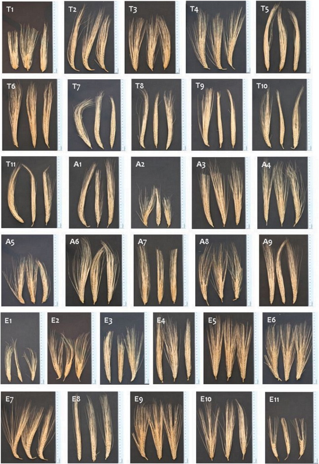

Fig. 1. Macroscopic appearance of spike diversity in North African barley used in this study (3 specimens were illustrated from each landraces).

T1: Kebili2, T2: Tozeur2, T3: Rihane, T4: Manel, T5: Jerba, T6: Sidi Bouzid, T7: Kairouan, T8: Gabès, T9: Touzeur1, T10: Tombari, T11: Kerkennah, A1: Sidi Mehdi, A2: Ras el Mouche, A3: Ksar Megarine, A4: Saida, A5: Azrir, A6: Rihane 03, A7: Tichedrett, A8: Nailia, A9: Temacine, E1: Early1, E2: Early2, E3: Giza123, E4: Giza125, E5: Giza126, E6: Giza127, E7: Giza129, E8: Giza130, E9: Giza131, E10: Giza2000, E11: El Arich.

#### 3.1.2. Cluster analysis of morphometric traits

The pair-wise similarity values of morphometric data obtained within the 31 landraces of barley ranged from 0.834 to 0.998. Based on Jaccard's similarity coefficients, a maximum similarity value was observed between T5 and T7 accessions, indicating an important genetic similarity between them. Conversely, T1 and A3 genotypes displayed the lowest similarity coefficient. Average similarity across all landraces was 0.916. As revealed by UPGMA clustering, all accessions were classified into three clusters (Fig. 2a). Hereafter, two major groups comprised 18 and 12 accessions respectively; Early2 genotype formed a group by itself. Agronomically superior barley landraces were included in cluster I which named as a high yielding cluster group. This cluster consists mainly of six rowed type with high yield potential (grain yield and spike dry weight), high filling capacity (high spikelet and grain number per plant/per spike), high heading capacity (high spike number), high tillering capacity, high shoot and whole plant biomass production and high leaf production. In contrast, the second cluster named as low yielding cluster group was characterized by low grain yield with small vegetative part production. This cluster was the most discriminative.

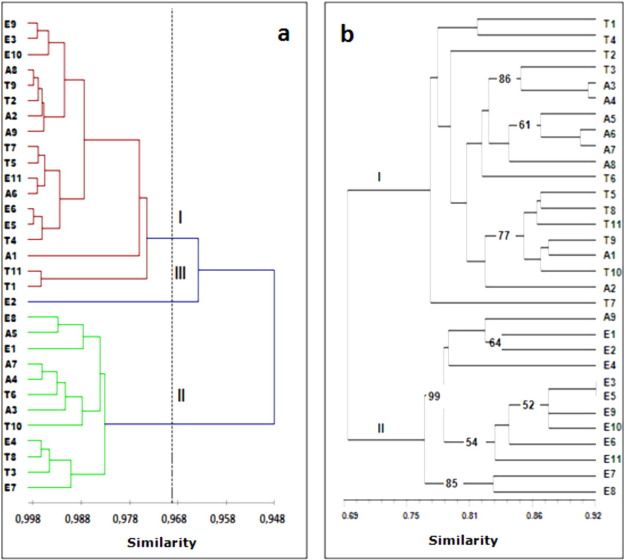

Fig. 2. [Dendrograms](https://www.sciencedirect.com/topics/agricultural-and-biological-sciences/dendrogram) of cluster analysis highlighting phylogenetic relationships among barley [landraces](https://www.sciencedirect.com/topics/agricultural-and-biological-sciences/landrace) based on agro-morphological (a) and [RAPD](https://www.sciencedirect.com/topics/agricultural-and-biological-sciences/rapd) molecular markers (b). Numbers of branches indicate bootstrap support out of 1000 replications. Bootstrap values > 50 are given at the branch points.

Based on morphological data, cluster analysis assigned the landraces from the same region, city or country in the same subgroup. This fact was shown for Egyptian landraces with two subgroups: Giza131, Giza123 and Giza2000 along with Giza126 and Giza127. Similar results were found for Algerian (Tichedrett and Saida) and Tunisian landraces (Kerkennah and Kebili) which are grouped in the same subgroup respectively (Fig. 2a). In addition, it was observed elsewhere that genotypes from neighboring countries (Tunisia and Algeria) were clustered together in two minor groups which reflect a close relationship based on geographical proximity. The first one contained: Nailia, Tozeur1, Tozeur2, Ras El Mouch and Temassine. The second group comprised: Tichedrett, Saida, Sidi Bouzid, Ksar-Megarine and Tombari.

### 3.2. RAPD profiling

#### 3.2.1. Assessment of discriminating capacity of RAPD markers

Thirty one barley varieties and accessions were chosen for RAPD polymorphism. Among 12 decamer [oligonucleotides](https://www.sciencedirect.com/topics/agricultural-and-biological-sciences/oligonucleotide) selected, 10 yielded a positive and repeatable banding pattern of amplification products and thus were selected for the RAPD analysis. PCR amplification of the [genomic DNA](https://www.sciencedirect.com/topics/agricultural-and-biological-sciences/genomic-dna) isolated from the 31 barley accessions yielded a total of 132 bands, of which 114 were polymorphic (86.36%) and 18 were monomorphic (Table 3). Overall size of the PCR amplified fragments ranged from 200 to 2750 bp. The banding pattern of barley genotypes has been shown for the primers OPB-01, OPA-04 and OPA-11 (Fig. 3). The total number of amplified DNA bands ranged from 9 (OPC 10) to 18 (OPA 11), with an average of 13.2 bands per primer. The present study showed a relatively high level of polymorphism (60.16%) across all the 31 barley landraces ranged from 41% (primer OPA-11) to 76.8% (OPC-06).

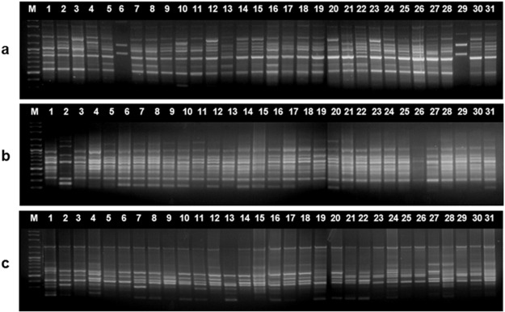

Fig. 3. [Agarose gel electrophoresis](https://www.sciencedirect.com/topics/agricultural-and-biological-sciences/agarose-gel-electrophoresis) of randomly primed DNA amplifications of barley leaf tissues with primers OPB-01 (panel “a”), OPA-04 (panel “b”) and OPA-11 (panel “c”). M refers to the 100 bp DNA ladder (Biobasic Inc.). Lines 1 to 31 indicate the accession number (see Table 1).

#### 3.2.2. Population genetic structure and level of genetic diversity in barley

Table 4. Genetic structure and level of genetic diversity in barley genotypes. Analysis of [genetic polymorphism](https://www.sciencedirect.com/topics/agricultural-and-biological-sciences/genetic-polymorphism) obtained with RAPD primers in different barley populations.

| Empty Cell | Population | Na | Ne | h | I | PPL% |
| --- | --- | --- | --- | --- | --- | --- |
| 1 | Tunisia | 1.575 | 1.304 | 0.185 | 0.284 | 57.58% |
| 2 | Algeria | 1.553 | 1.295 | 0.179 | 0.274 | 55.30% |
| 3 | Egypt | 1.590 | 1.297 | 0.182 | 0.282 | 58.33% |

Na: observed no. of alleles; Ne: effective no. of alleles; h: Nei's gene diversity; I: Shannon's information index; PPL: percentage of polymorphic loci.

Table 5. Genetic differentiation and gene flow among and within the barley populations.

| Total geographical populations | No. of individuals | HT | HS | G<sub>ST</sub> | Nm |
| --- | --- | --- | --- | --- | --- |
| 3 | 31 | 0.246 ± 0.033 | 0.182 ± 0.018 | 0.257 | 1.439 |

HT: total genetic diversity among populations; HS: genetic diversity within a population; G<sub>ST</sub>: genetic diversity index among populations; Nm: gene flow among populations.

#### 3.2.3. Genetic diversity and relationships

The relationships among populations were also evaluated using Nei's unbiased distance matrix (Table 6). The distance between groups' similarity matrix showed that the high divergence among population appears when population 1 (Tunisia) and population 3 (Egypt) are compared with each other. In contrast, Nei's genetic identity coefficient among population 1 (Tunisia) to population 2 (Algeria) was higher (0.956), while the corresponding genetic distance was lower (0.044) since Tunisia and Algeria represent neighboring countries. G<sub>ST</sub> value indicates whether the majority of genetic variation is within a population or among populations. G<sub>ST</sub> value near to 1.0 indicates a majority of genetic variability among populations. Conversely, a lower G<sub>ST</sub> value suggests a majority of genetic variability within a given population. The G<sub>ST</sub> value was 0.257, indicating that 25.7% of gene differentiation occurred among barley populations and 74.3% occurred within populations. These results indicate a relatively high level of genetic differentiation within the populations. The Mantel test of data for three populations showed no significant correlation between genetic distances and corresponding morphological distances (R<sup>2</sup> = 0.001, p = 0.492).

Table 6. Nei's genetic identity (above diagonal) and genetic distance (below diagonal) analysis.

| Empty Cell | Tunisia | Algeria | Egypt |
| --- | --- | --- | --- |
| Tunisia | **** | 0.9564 | 0.8317 |
| Algeria | 0.0446 | **** | 0.8624 |
| Egypt | 0.1842 | 0.1481 | **** |

## 4. Discussion

In this study, some qualitative characters based on IPGRI descriptors seem to be related to geographic provenance. Regarding morphological characterization, our results showed a definite dissimilarity between the set of accessions from Egypt and the set including both Tunisian and Algerian genotypes for the following traits: the lemma awn barbs, the length of glume and glume awn and the length of rachilla hair. Some traits were country-related: i.e. lemma awn barbs from Tunisia and Algeria, which are neighboring countries, were generally rough, while Egyptian collection was heterogeneous and containing some accessions with lemma awn barbs intermediate. In the same way, the length of glume and glume awn was generally as long as kernel for Tunisia and Algeria, whereas accessions from Egypt had commonly glume plus awn longer than or nearly twice as long as kernel. Similarly, we observed short rachilla hair for Tunisian and Algerian landraces while the majority of Egyptian genotypes had long rachilla hair. Taking together, we selected some qualitative traits – such as number of rows and fragility of rachis – useful as discriminating tools that could provide key characters for yield improvement. The grain yield is particularly important and constitutes the main objective in breeding programs. Hence, three key traits – selection for non-brittle rachis, six-rowed spike and naked caryopsis – were involved in barley domestication (Zohary and Hopf, 2000, Salamini et al., 2002, Barabashi et al., 2012). In this way, the present study showed that cluster analysis using morphological traits discriminated clearly high and low-yielding barley. Barley with high [biomass production](https://www.sciencedirect.com/topics/agricultural-and-biological-sciences/biomass-production) (grouped in cluster I) was far away from low biomass production group (cluster II) which seems to be the nearest to the barley origin ancestor. The naked barleys included in cluster II were poor yielding as well as poor thousand kernel weight. Previous reports have demonstrated that the naked gene has multiple effects on many traits, like yield reduction and lower seed weight and suggested a closer relationship of naked barley with the ancestor providing an obvious implication that naked accessions have been diverged for long time ago from the barley progenitor (Choo et al., 2001, Pourkheirandish and Komatsuda, 2007, Barabashi et al., 2012).

Morphological markers are prone to equivocal interpretations and are time-consuming to assess, not always available for analysis, and affected by environmental conditions. Therefore, PCR-based molecular marker technology is receiving much attention and has several advantages over the single use of conventional markers in [cultivar identification](https://www.sciencedirect.com/topics/agricultural-and-biological-sciences/cultivar-identification) and breeding programs. Here, RAPD was used as it remains a valuable approach to assess genetic diversity and to discriminate between barley accessions (Fernandez et al., 2002, Tanyolac, 2003, Guasmi et al., 2012). RAPD-based monitoring of the genetic variability of North African barley collection demonstrated high polymorphism among genotypes. This finding was noted also in rice (Saker et al., 2005) and orange (Lamine and Mliki, 2015) stating that RAPD markers were commonly used to discriminate minimal divergence between clones, sometimes more efficiently than SSR markers in the capacity of revealing more informative data for characterizing closely related accessions. In fact, several studies dealing with comparison of molecular markers for fingerprinting purpose found that the efficiency of RAPD compared to other structural and gene-targeted markers was relatively the same and that there were no significant differences among them, highlighting that RAPD technique was recommended in previous and recent investigations as efficient tool in terms of genotypic evaluation in various plant species (McGregor et al., 2000, Arif et al., 2009, Gorji et al., 2011, Izzatullayeva et al., 2014, Lamine and Mliki, 2015, Vaja et al., 2016). In the other hand, some current studies reported that using RAPD individually or combined with other markers does not bring supplementary information for establishing genetic relationship among studied cultivars or accessions (Gorji et al., 2011, Lamine and Mliki, 2015, Ntuli et al., 2015, Thakur et al., 2016).

In our study, the dendrogram constructed using UPGMA from RAPD-based genetic similarity matrix showed that group structure is dependent on [geographical distribution](https://www.sciencedirect.com/topics/agricultural-and-biological-sciences/geographical-distribution). As expected, clustering highlighted accessions with the same geographic origin. Specifically, molecular data distinguished two major groups; landraces from the western part of the distribution area (Tunisia and Algeria) were assigned together into the same group, and a second group was comprised of geographically distant accessions from the east (i.e. Egypt). This pattern of geographically-related grouping by molecular markers has also been described in wheat (Ates Sönmezoglu et al., 2012) and summer squash (Ntuli et al., 2015). However, our data do not agree with previous reports on barley and *[Aegilops](https://www.sciencedirect.com/topics/agricultural-and-biological-sciences/aegilops)* (Strelchenko et al., 1999, Owuor et al., 2003, Mahjoub et al., 2009) which state that barley does not cluster molecularly in ways that reflect geographic provenance. RAPD profiling was also effective in discriminating between naked and covered barleys; the UPGMA tree for the second cluster comprised of Egyptian genotypes, showed a separate subgroup that included naked barleys, (Giza129 and Giza130) and that appeared distinct from covered barleys as described by Manjunatha et al. (2007).

The hulled or naked caryopsis character of barley is an important [agronomic trait](https://www.sciencedirect.com/topics/agricultural-and-biological-sciences/agronomic-trait) because of its direct link to dietary use. The remains of naked kernels dating from about 8000 BP have been found in Ali Kosh, which indicates that a mutation for this trait occurred early in the domestication process of barley (Helbaek, 1969). Accordingly, Murphy and Witcombe (1986) suggested that naked barleys arose from covered barleys via a single gene mutation a long time ago, and that thereafter cultural and adaptive selection pressures caused these forms to diverge. Additionally, based on combined results connecting molecular with quantitative data, RAPD markers were suitable to differentiate accessions according to the glume awn type. Effectively, as shown with the RAPD-dendrogram (Fig. 2b), the Egyptian cluster (cluster II) was subdivided to three major subgroups which is in agreement with differentially-structured glume awn. This finding suggested the significance of RAPD markers connected with gene-related traits involved in quality and phenotypic characters that could help to give us new insights towards marker-assisted selection in barley.

## 5. Conclusion

Morphological and RAPD-based clusters and their accompanying analyses showed different hierarchical patterns of genetic diversity among the accessions. Despite their disparity, the two approaches were found independently useful for assessing the degree of relatedness and the overall patterns of genetic variation among the analyzed barley cultivars. However, molecular markers provide powerful tools in the evaluation of intra-specific relationship and were more effective in grouping barley genotypes. Investigating the genetic structure of barley germplasm of some North African countries based on phenotypic and molecular variability remains of significant importance for genetic improvement and elite gene exploitation. Furthermore, techniques and obtained data are expected to be applicable for further works, such as marker-assisted breeding, genetic comparative mapping and association studies.

## Conflict of interest

The authors declare that there is no conflict of interests regarding the publication of this work.

## Acknowledgments

This work was supported by NEPAD-NABnet (New partnership for African's Development — North Africa Barley) project and a personal grant to Dorsaf Allel from Mitsubishi Corporation (Japan). Authors are grateful to Dr. Claudia Copeland and Dr. Jessica Ward for scientific proofreading this manuscript. We thank also Mahmoud Sakr (NRC, Egypt), Ahmed Nada (AGERI, Egypt), M'barek Ben Naceur (INRAT, Tunisia) and Dalila Ramla (INRA, Algeria) for kindly providing barley accessions.

## References

1. Allel et al., 2016

   D. Allel, A. Ben-Amar, M. Badri, C. Abdelly

   Salt tolerance in barley originating from harsh environment of North Africa

   Australian Journal of Crop Science, 10 (2016), pp. 438-451

   [CrossRef](https://doi.org/10.21475/ajcs.2016.10.04.p6663x)[View in Scopus](https://www.scopus.com/inward/record.url?eid=2-s2.0-84971633048&partnerID=10&rel=R3.0.0)Google Scholar
2. Arif et al., 2009

   M. Arif, N.W. Zaidi, Y.P. Singh

   A comparative analysis of ISSR and RAPD markers for study of genetic diversity in Shisham (*Dalbergia sissoo*)

   Plant Molecular Biology Reporter, 27 (2009), pp. 488-495

   [CrossRef](https://doi.org/10.1007/s11105-009-0097-0)[View in Scopus](https://www.scopus.com/inward/record.url?eid=2-s2.0-70350367371&partnerID=10&rel=R3.0.0)[Google Scholar](https://scholar.google.com/scholar?q=A%20comparative%20analysis%20of%20ISSR%20and%20RAPD%20markers%20for%20study%20of%20genetic%20diversity%20in%20Shisham)
3. Asfaw and von Bothmer, 1990

   Z. Asfaw, R. von Bothmer

   Hybridization between landrace varieties of Ethiopian barley (*Hordeum vulgare* ssp. *vulgare*) and the progenitor of barley (*H. vulgare* ssp. *spontaneum*)

   Hereditas, 112 (1990), pp. 57-64

   [View in Scopus](https://www.scopus.com/inward/record.url?eid=2-s2.0-0025297686&partnerID=10&rel=R3.0.0)[Google Scholar](https://scholar.google.com/scholar?q=Hybridization%20between%20landrace%20varieties%20of%20Ethiopian%20barley%20%20and%20the%20progenitor%20of%20barley)
4. Ates Sönmezoglu et al., 2012

   O. Ates Sönmezoglu, B. Bozmaz, A. Yildirim, N. Kandemir, N. Aydin

   Genetic characterization of Turkish bread wheat landraces based on microsatellite markers and morphological characters

   Turkish Journal of Biology, 36 (2012), pp. 589-597

   [View in Scopus](https://www.scopus.com/inward/record.url?eid=2-s2.0-84865815665&partnerID=10&rel=R3.0.0)Google Scholar
5. Badr et al., 2000

   A. Badr, K. Muller, R. Schafer-Pregl, H. El Rabey, S. Effgen, H.H. Ibrahim, C. Pozzi, W. Rohde, F. Salamini

   On the origin and domestication history of barley (*Hordeum vulgare*)

   Molecular Biology and Evolution, 17 (2000), pp. 499-510

   [CrossRef](https://doi.org/10.1093/oxfordjournals.molbev.a026330)[View in Scopus](https://www.scopus.com/inward/record.url?eid=2-s2.0-0343238443&partnerID=10&rel=R3.0.0)[Google Scholar](https://scholar.google.com/scholar?q=On%20the%20origin%20and%20domestication%20history%20of%20barley)
6. Bahrman et al., 1999

   N. Bahrman, J. Le Gouis, D. Hariri, L. Guilbaud, L. Jestin

   Genetic diversity of old French six rowed winter barley varieties assessed with molecular, biochemical and morphological markers and its relation to BaMMV resistance

   Heredity, 83 (1999), pp. 568-574

   [CrossRef](https://doi.org/10.1038/sj.hdy.6886140)[View in Scopus](https://www.scopus.com/inward/record.url?eid=2-s2.0-0344991696&partnerID=10&rel=R3.0.0)Google Scholar
7. Barabashi et al., 2012

   D. Barabashi, E. Francia, A. Tondelli, A. Gianinetti, A.M. Stanca, N. Pecchioni

   Effect of the nud gene on grain yield in barley

   Czech Journal of Genetics and Plant Breeding, 48 (2012), pp. 10-22

   Google Scholar
8. Baum et al., 1997

   B.R. Baum, E. Nevo, D.A. Johnson, A. Beiles

   Genetic diversity in wild barley (*Hordeum spontaneum* C. Koch) in the Near East: a molecular analysis using Random Amplified Polymorphic DNA (RAPD) markers

   Genetic Resources and Crop Evolution, 44 (1997), pp. 147-157

   [View in Scopus](https://www.scopus.com/inward/record.url?eid=2-s2.0-0030613352&partnerID=10&rel=R3.0.0)[Google Scholar](https://scholar.google.com/scholar?q=Genetic%20diversity%20in%20wild%20barley%20%20in%20the%20Near%20East:%20a%20molecular%20analysis%20using%20Random%20Amplified%20Polymorphic%20DNA%20%20markers)
9. Bellucci et al., 2013

   E. Bellucci, E. Bitocchi, D. Rau, L. Nanni, N. Ferradini, A. Giardini, M. Rodriguez, G. Attene, R. Papa

   Population structure of barley landrace populations and gene-flow with modern varieties

   PloS One, 8 (2013), Article e83891

   [CrossRef](https://doi.org/10.1371/journal.pone.0083891)[View in Scopus](https://www.scopus.com/inward/record.url?eid=2-s2.0-84893522272&partnerID=10&rel=R3.0.0)Google Scholar
10. Bothmer et al., 2003

    R. Bothmer, T. Van Hintum, H. Knuoffer, K. Sato

    Diversity in Barley *Hordeum vulgare* L

    Elsevier Science (2003)

    (280 pp.)

    [Google Scholar](https://scholar.google.com/scholar_lookup?title=Diversity%20in%20Barley%20Hordeum%20vulgare%20L&publication_year=2003&author=R.%20Bothmer&author=T.%20Van%20Hintum&author=H.%20Knuoffer&author=K.%20Sato)
11. Brush, 1995

    S.B. Brush

    In situ conservation of landraces in centers of crop diversity

    Crop Science, 35 (1995), pp. 346-354

    [Google Scholar](https://scholar.google.com/scholar_lookup?title=In%20situ%20conservation%20of%20landraces%20in%20centers%20of%20crop%20diversity&publication_year=1995&author=S.B.%20Brush)
12. Canci et al., 2003

    P.C. Canci, L.M. Nduulu, R. Dill-Macky, G.J. Muehlbauer, D.C. Rasmusson, K.P. Smith

    Genetic relationship between kernel discoloration and grain protein concentration in barley

    Crop Science, 43 (2003), pp. 1671-1679

    [CrossRef](https://doi.org/10.2135/cropsci2003.1671)[View in Scopus](https://www.scopus.com/inward/record.url?eid=2-s2.0-0141794112&partnerID=10&rel=R3.0.0)Google Scholar
13. Choo et al., 2001

    T.M. Choo, K.M. Ho, R.A. Martin

    Genetic analysis of a hulless × covered cross of barley using double-haploid lines

    Crop Science, 41 (2001), pp. 1021-1026

    [CrossRef](https://doi.org/10.2135/cropsci2001.4141021x)[View in Scopus](https://www.scopus.com/inward/record.url?eid=2-s2.0-0034887984&partnerID=10&rel=R3.0.0)Google Scholar
14. Dakir et al., 2002

    E.H. Dakir, M.L. Ruiz, P. Garcia, M.P. de la Vega

    Genetic variability evaluation of a Moroccan collection of barley, *Hordeum vulgare* L., by means of storage proteins and RAPDs

    Genetic Resources and Crop Evolution, 49 (2002), pp. 619-631

    [View in Scopus](https://www.scopus.com/inward/record.url?eid=2-s2.0-0036910586&partnerID=10&rel=R3.0.0)Google Scholar
15. Doyle and Doyle, 1987

    J.J. Doyle, L. Doyle

    A rapid DNA isolation procedure for small quantities of fresh leaf tissue

    Phytochemical Bulletin, Columbus, 19 (1987), pp. 11-15

    [Google Scholar](https://scholar.google.com/scholar_lookup?title=A%20rapid%20DNA%20isolation%20procedure%20for%20small%20quantities%20of%20fresh%20leaf%20tissue&publication_year=1987&author=J.J.%20Doyle&author=L.%20Doyle)
16. Eshghi and Akhundova, 2010

    R. Eshghi, E. Akhundova

    Genetic diversity in hulless barley based on agromorphological traits and RAPD markers and comparison with storage protein analysis

    African Journal of Agricultural Research, 5 (2010), pp. 97-107

    [View in Scopus](https://www.scopus.com/inward/record.url?eid=2-s2.0-79951922328&partnerID=10&rel=R3.0.0)Google Scholar
17. Fernandez et al., 2002

    M.E. Fernandez, A.M. Figueiras, C. Benito

    The use of ISSR and RAPD markers for detecting DNA polymorphism, genotype identification and genetic diversity among barley cultivars with known origin

    Theoretical and Applied Genetics, 104 (2002), pp. 845-851

    [View in Scopus](https://www.scopus.com/inward/record.url?eid=2-s2.0-0036923637&partnerID=10&rel=R3.0.0)Google Scholar
18. Francisco-Ortega et al., 2000

    J. Francisco-Ortega, A. Santos-Guerra, S.C. Kim, D.J. Crawford

    Plant genetic diversity in the Canary Islands: a conservation perspective

    American Journal of Botany, 87 (2000), pp. 909-919

    [CrossRef](https://doi.org/10.2307/2656988)[View in Scopus](https://www.scopus.com/inward/record.url?eid=2-s2.0-0033927817&partnerID=10&rel=R3.0.0)Google Scholar
19. Gorji et al., 2011

    A.M. Gorji, P. Poczai, Z. Polgar, J. Taller

    Efficiency of arbitrarily amplified dominant markers (SCOT, ISSR and RAPD) for diagnostic fingerprinting in tetraploid potato

    American Journal of Potato Research, 88 (2011), pp. 226-237

    [CrossRef](https://doi.org/10.1007/s12230-011-9187-2)[View in Scopus](https://www.scopus.com/inward/record.url?eid=2-s2.0-79956357854&partnerID=10&rel=R3.0.0)[Google Scholar](https://scholar.google.com/scholar?q=Efficiency%20of%20arbitrarily%20amplified%20dominant%20markers%20%20for%20diagnostic%20fingerprinting%20in%20tetraploid%20potato)
20. Guasmi et al., 2012

    F. Guasmi, W. Elfalleh, H. Hannachi, K. Feres, L. Touil, N. Marzougui, T. Triki, A. Ferchichi

    The use of ISSR and RAPD markers for genetic diversity among South Tunisian barley

    International Scholarly Research Network, ISRN Agronomy (2012), 10.5402/2012/952196

    Google Scholar
21. Hamza et al., 2004

    S. Hamza, W.B. Hamida, A. Rebai, M. Harrabi

    SSR-based genetic diversity assessment among Tunisian winter barley and relationship with morphological traits

    Euphytica, 135 (2004), pp. 107-118

    [View in Scopus](https://www.scopus.com/inward/record.url?eid=2-s2.0-0742267786&partnerID=10&rel=R3.0.0)Google Scholar
22. Helbaek, 1969

    H. Helbaek

    Plant-collecting, dry-farming and irrigation agriculture in prehistoric Deh Luran

    F. Hole, K.V. Flannery, J.A. Neely (Eds.), Prehistory and Human Ecology of the Deh Luran Plain. An Early Village Sequence from Khuzistan, Iran, University of Michigan: Memoirs of the Museum of Anthropology (1969), pp. 383-426

    [Google Scholar](https://scholar.google.com/scholar_lookup?title=Plant-collecting%2C%20dry-farming%20and%20irrigation%20agriculture%20in%20prehistoric%20Deh%20Luran&publication_year=1969&author=H.%20Helbaek)
23. Hoffman and Bregitzer, 1996

    D.L. Hoffman, P. Bregitzer

    Identification of reproducible PCR-RAPD markers that enable the identification of closely related six-rowed malting barley (*Hordeum vulgare* L.) cultivars

    Journal of American Society Brewing Chemists, 54 (1996), pp. 172-176

    [CrossRef](https://doi.org/10.1094/asbcj-54-0172)[View in Scopus](https://www.scopus.com/inward/record.url?eid=2-s2.0-0000239141&partnerID=10&rel=R3.0.0)[Google Scholar](https://scholar.google.com/scholar?q=Identification%20of%20reproducible%20PCR-RAPD%20markers%20that%20enable%20the%20identification%20of%20closely%20related%20six-rowed%20malting%20barley%20%20cultivars)
24. Izzatullayeva et al., 2014

    V. Izzatullayeva, Z. Akaparov, S. Babayeva, J. Ojaghi, M. Abbasov

    Efficiency of using RAPD and ISSR markers in evaluation of genetic diversity in sugar beet

    Turkish Journal of Biology, 38 (2014), pp. 429-438

    [CrossRef](https://doi.org/10.3906/biy-1312-35)[View in Scopus](https://www.scopus.com/inward/record.url?eid=2-s2.0-84901807559&partnerID=10&rel=R3.0.0)Google Scholar
25. Jilal, 2011

    A. Jilal

    Assessment of Genetically Diverse International Barley Germplasm for Development of Food Product Applications

    (Ph.D. Thesis)

    Southern Cross University, Lismore, NSW, Australia (2011)

    Google Scholar
26. Kimura and Weiss, 1964

    M. Kimura, G.H. Weiss

    The stepping stone model of population structure and decrease of genetic correlation with distance

    Genetics, 49 (1964), pp. 561-567

    [CrossRef](https://doi.org/10.1093/genetics/49.4.561)Google Scholar
27. Koebner et al., 2002

    R.M.D. Koebner, P. Donini, J.C. Reeves, R.J. Cooke, J.R. Law

    Temporal flux in the morphological and molecular diversity of UK barley

    Theoretical and Applied Genetics, 106 (2002), pp. 550-558

    Google Scholar
28. Lamine and Mliki, 2015

    M. Lamine, A. Mliki

    Elucidating genetic diversity among sour orange rootstocks: a comparative study of the efficiency of RAPD and SSR markers

    Applied Biochemistry and Biotechnology, 175 (2015), pp. 2996-3013

    [CrossRef](https://doi.org/10.1007/s12010-015-1477-6)[View in Scopus](https://www.scopus.com/inward/record.url?eid=2-s2.0-84924062156&partnerID=10&rel=R3.0.0)Google Scholar
29. Laugesen et al., 2007

    S. Laugesen, K.S. Bak-Jensen, P. Hagglund, A. Henriksen, C. Finnie, B. Svensson, P. Roepstorff

    Barley peroxidase isozymes: expression and post-translational modification in mature seeds as identified by two-dimensional gel electrophoresis and mass spectrometry

    International Journal of Mass Spectrometry, 268 (2007), pp. 244-253

    [View PDF](https://www.sciencedirect.com/science/article/pii/S1387380607002424/pdfft?md5=13310daf16f7ad7a8d2b6b6f3f54d863&pid=1-s2.0-S1387380607002424-main.pdf)[View article](https://www.sciencedirect.com/science/article/pii/S1387380607002424)[View in Scopus](https://www.scopus.com/inward/record.url?eid=2-s2.0-35748942555&partnerID=10&rel=R3.0.0)Google Scholar
30. Lewontin, 1972

    R.C. Lewontin

    Testing the theory of natural selection

    Nature, 236 (1972), pp. 181-182

    [CrossRef](https://doi.org/10.1038/236181a0)[Google Scholar](https://scholar.google.com/scholar_lookup?title=Testing%20the%20theory%20of%20natural%20selection&publication_year=1972&author=R.C.%20Lewontin)
31. Mahjoub et al., 2009

    A. Mahjoub, M.S. El Gharbi, K. Mguis, M. El Gazzah, N.B. Brahim

    Evaluation of genetic diversity in *Aegilops geniculata* Roth accessions using morphological and RAPD markers

    Pakistan Journal of Biological Sciences, 12 (2009), pp. 994-1003

    [CrossRef](https://doi.org/10.3923/pjbs.2009.994.1003)[View in Scopus](https://www.scopus.com/inward/record.url?eid=2-s2.0-73949112098&partnerID=10&rel=R3.0.0)Google Scholar
32. Manjunatha et al., 2007

    T. Manjunatha, I.S. Bisht, K.V. Bhat, B.P. Singh

    Genetic diversity of barley (*Hordeum vulgare* L. ssp. *vulgare*) landraces from Uttaranchal Himalaya of India

    Genetic Resources and Crop Evolution, 54 (2007), pp. 55-65

    [CrossRef](https://doi.org/10.1007/s10722-005-1884-6)[View in Scopus](https://www.scopus.com/inward/record.url?eid=2-s2.0-33846297356&partnerID=10&rel=R3.0.0)[Google Scholar](https://scholar.google.com/scholar?q=Genetic%20diversity%20of%20barley%20%20landraces%20from%20Uttaranchal%20Himalaya%20of%20India)
33. McGregor et al., 2000

    C.E. McGregor, C.A. Lambert, M.M. Greyling, J.H. Louw, L. Warnich

    A comparative assessment of DNA fingerprinting techniques (RAPD, ISSR, AFLP and SSR) in tetraploid potato (*Solanum tuberosum* L.) germplasm

    Euphytica, 113 (2000), pp. 135-144

    [View in Scopus](https://www.scopus.com/inward/record.url?eid=2-s2.0-0034128259&partnerID=10&rel=R3.0.0)[Google Scholar](https://scholar.google.com/scholar?q=A%20comparative%20assessment%20of%20DNA%20fingerprinting%20techniques%20%20in%20tetraploid%20potato%20%20germplasm)
34. Mohamed et al., 2010

    A.A. Mohamed, M.A. Matter, M.R. Rady

    Assessment of some barley germplasms based on RAPD analysis and anti-nutritional factors

    Journal of Crop Science and Biotechnology, 13 (2010), pp. 61-68

    [CrossRef](https://doi.org/10.1007/s12892-010-0010-2)Google Scholar
35. Molina-Cano et al., 2005

    J.L. Molina-Cano, J.R. Russell, M.A. Moralejo, J.L. Escacena, G. Arias, W. Powell

    Chloroplast DNA microsatellite analysis supports a polyphyletic origin for barley

    Theoretical and Applied Genetics, 110 (2005), pp. 613-619

    [CrossRef](https://doi.org/10.1007/s00122-004-1878-3)[View in Scopus](https://www.scopus.com/inward/record.url?eid=2-s2.0-15244363691&partnerID=10&rel=R3.0.0)Google Scholar
36. Morrell and Clegg, 2007

    P.L. Morrell, M.T. Clegg

    Genetic evidence for a second domestication of barley (*Hordeum vulgare*) east of the Fertile Crescent

    Proceedings of the National Academy of Sciences of the United States of America, 104 (2007), pp. 3289-3294

    [CrossRef](https://doi.org/10.1073/pnas.0611377104)[View in Scopus](https://www.scopus.com/inward/record.url?eid=2-s2.0-33847636042&partnerID=10&rel=R3.0.0)[Google Scholar](https://scholar.google.com/scholar?q=Genetic%20evidence%20for%20a%20second%20domestication%20of%20barley%20%20east%20of%20the%20Fertile%20Crescent)
37. Murphy and Witcombe, 1986

    P.J. Murphy, J.R. Witcombe

    Covered and naked barleys from the Himalaya. 1. Evidence of multivariate differences between two types

    Theoretical and Applied Genetics, 71 (1986), pp. 730-735

    [CrossRef](https://doi.org/10.1007/bf00263271)[View in Scopus](https://www.scopus.com/inward/record.url?eid=2-s2.0-33746444559&partnerID=10&rel=R3.0.0)Google Scholar
38. Nei, 1972

    M. Nei

    Genetic distance between populations

    American Naturalist, 106 (1972), pp. 283-292

    [Google Scholar](https://scholar.google.com/scholar_lookup?title=Genetic%20distance%20between%20populations&publication_year=1972&author=M.%20Nei)
39. Nei, 1973

    M. Nei

    Analysis of gene diversity in subdivided populations

    Proceedings of the National Academy of Sciences of the United States of America, 70 (1973), pp. 3321-3323

    [CrossRef](https://doi.org/10.1073/pnas.70.12.3321)[View in Scopus](https://www.scopus.com/inward/record.url?eid=2-s2.0-0006919926&partnerID=10&rel=R3.0.0)[Google Scholar](https://scholar.google.com/scholar_lookup?title=Analysis%20of%20gene%20diversity%20in%20subdivided%20populations&publication_year=1973&author=M.%20Nei)
40. Nei and Li, 1979

    M. Nei, W.H. Li

    Mathematical models for studying genetic variation in terms of restriction endonucleases

    Proceedings of the National Academy of Sciences of the United States of America, 76 (1979), pp. 5269-5273

    [CrossRef](https://doi.org/10.1073/pnas.76.10.5269)[View in Scopus](https://www.scopus.com/inward/record.url?eid=2-s2.0-0005814023&partnerID=10&rel=R3.0.0)Google Scholar
41. Nei and Roychoudhury, 1974

    M. Nei, A.K. Roychoudhury

    Sampling variances of heterozygosity and genetic distance

    Genetics, 76 (1974), pp. 379-390

    [CrossRef](https://doi.org/10.1093/genetics/76.2.379)[View in Scopus](https://www.scopus.com/inward/record.url?eid=2-s2.0-0015990369&partnerID=10&rel=R3.0.0)[Google Scholar](https://scholar.google.com/scholar_lookup?title=Sampling%20variances%20of%20heterozygosity%20and%20genetic%20distance&publication_year=1974&author=M.%20Nei&author=A.K.%20Roychoudhury)
42. Nevo et al., 1998

    E. Nevo, B. Baum, A. Beiles, D.A. Johnson

    Ecological correlates of RAPD DNA diversity of wild barley, *Hordeum spontaneum*, in the Fertile Crescent

    Genetic Resources and Crop Evolution, 45 (1998), pp. 151-159

    [View in Scopus](https://www.scopus.com/inward/record.url?eid=2-s2.0-0031981245&partnerID=10&rel=R3.0.0)Google Scholar
43. Ntuli et al., 2015

    N.R. Ntuli, P.B. Tongoona, A.M. Zobolo

    Genetic diversity in *Cucurbita pepo* landraces revealed by RAPD and SSR markers

    Scientia Horticulturae, 189 (2015), pp. 192-200

    [View PDF](https://www.sciencedirect.com/science/article/pii/S0304423815001399/pdfft?md5=1780e35e79d059993c0ec685b4492113&pid=1-s2.0-S0304423815001399-main.pdf)[View article](https://www.sciencedirect.com/science/article/pii/S0304423815001399)[View in Scopus](https://www.scopus.com/inward/record.url?eid=2-s2.0-84928338526&partnerID=10&rel=R3.0.0)Google Scholar
44. Orabi et al., 2007

    J. Orabi, G. Backes, A. Wolday, A. Yahyaoui, A. Jahoor

    The Horn of Africa as a centre of barley diversification and a potential domestication site

    Theoretical and Applied Genetics, 114 (2007), pp. 1117-1127

    [CrossRef](https://doi.org/10.1007/s00122-007-0505-5)[View in Scopus](https://www.scopus.com/inward/record.url?eid=2-s2.0-34047124194&partnerID=10&rel=R3.0.0)Google Scholar
45. Owuor et al., 2003

    E.D. Owuor, A. Beharav, T. Fahima, V.M. Kirzhner, A.B. Korol, E. Nevo

    Microscale ecological stress causes RAPD molecular selection in wild barley, Neve Yaar microsite, Israel

    Genetic Resources and Crop Evolution, 50 (2003), pp. 213-224

    [View in Scopus](https://www.scopus.com/inward/record.url?eid=2-s2.0-0037679204&partnerID=10&rel=R3.0.0)Google Scholar
46. Pandey, 2006

    M.P. Pandey

    Molecular Assessment of Genetic Diversity and Population Differentiation of Hulles Barley (*Hordeum vulgare* L.) Landraces From the Himalayas of Nepal and Its Relevance for Barley Breeding

    (Ph.D. Thesis)

    Justus-Liebig-Universitat Giesen, Gemany (2006)

    Google Scholar
47. Poets et al., 2016

    A.M. Poets, M. Mohammadi, K. Seth, H. Wang, H.J.Y. Kono, Z. Fang, G.J. Muehlbauer, K.P. Smith, P.L. Morrell

    The effects of both recent and long-term selection and genetic drift are readily evident in North American barley breeding populations

    G3 (Bethesda) Genes Genomes Genetics, 6 (2016), pp. 609-622

    [CrossRef](https://doi.org/10.1534/g3.115.024349)[View in Scopus](https://www.scopus.com/inward/record.url?eid=2-s2.0-84959472916&partnerID=10&rel=R3.0.0)Google Scholar
48. Pourkheirandish and Komatsuda, 2007

    M. Pourkheirandish, T. Komatsuda

    The importance of barley genetics and domestication in a global perspective

    Annals of Botany, 100 (2007), pp. 999-1008

    [CrossRef](https://doi.org/10.1093/aob/mcm139)[View in Scopus](https://www.scopus.com/inward/record.url?eid=2-s2.0-35349019313&partnerID=10&rel=R3.0.0)Google Scholar
49. Qiu et al., 2011

    L. Qiu, D.Z. Wu, S. Ali, S.G. Cai, F. Dai, X. Jin, F. Wu, G. Zhang

    Evaluation of salinity tolerance and analysis of allelic function of HvHKT1 and HvHKT2 in Tibetan wild barley

    Theoretical and Applied Genetics, 122 (2011), pp. 695-703

    [CrossRef](https://doi.org/10.1007/s00122-010-1479-2)[View in Scopus](https://www.scopus.com/inward/record.url?eid=2-s2.0-79952452101&partnerID=10&rel=R3.0.0)Google Scholar
50. Raina et al., 2001

    S.N. Raina, V. Rani, T. Kojima, Y. Ogihara, K.P. Singh, R.M. Devarumath

    RAPD and ISSR fingerprints as useful genetic markers for analysis of genetic diversity, varietals identification, and phylogenetic relationships in peanut (*Arachis hypogaea*) cultivars and wild species

    Genome, 44 (2001), pp. 763-772

    [View in Scopus](https://www.scopus.com/inward/record.url?eid=2-s2.0-0034752623&partnerID=10&rel=R3.0.0)Google Scholar
51. Rohlf, 2000

    F.J. Rohlf

    NTSYS-pc, Numerical Taxonomy and Multivariate Analysis System. Applied Biostatistics, New York. NTSYS-PC. Numerical Taxonomy System

    Exeter Software, New York (2000)

    Google Scholar
52. Saisho and Purugganan, 2007

    D. Saisho, M.D. Purugganan

    Molecular phylogeography of domesticated barley traces expansion of agriculture in the old world

    Genetics, 177 (2007), pp. 1765-1776

    [CrossRef](https://doi.org/10.1534/genetics.107.079491)[View in Scopus](https://www.scopus.com/inward/record.url?eid=2-s2.0-37249022258&partnerID=10&rel=R3.0.0)Google Scholar
53. Saker et al., 2005

    M.M. Saker, S.S. Youssef, N.A. Abdallah, H.S. Bashandy, A.M. El Sharkawy

    Genetic analysis of some Egyptian rice genotypes using RAPD, SSR and AFLP

    African Journal of Biotechnology, 4 (2005), pp. 882-890

    [View in Scopus](https://www.scopus.com/inward/record.url?eid=2-s2.0-24944481542&partnerID=10&rel=R3.0.0)Google Scholar
54. Salamini et al., 2002

    F. Salamini, H. Özkan, A. Brandolini, R. Schäfer-Pregl, W. Martin

    Genetics and geography of wild cereal domestication in the near east

    Nature Reviews of Genetics, 3 (2002), pp. 429-441

    [CrossRef](https://doi.org/10.1038/nrg817)[View in Scopus](https://www.scopus.com/inward/record.url?eid=2-s2.0-0036272895&partnerID=10&rel=R3.0.0)Google Scholar
55. Shannon and Weaver, 1949

    C.E. Shannon, W. Weaver

    The Mathematical Theory of Communication

    University of Illinois Press, Urbana (1949)

    [Google Scholar](https://scholar.google.com/scholar_lookup?title=The%20Mathematical%20Theory%20of%20Communication&publication_year=1949&author=C.E.%20Shannon&author=W.%20Weaver)
56. Singh et al., 1998

    A.K. Singh, J. Smart, C.E. Simpson, S.N. Raina

    Genetic variation vis-à-vis molecular polymorphism in groundnut *Arachis hypogea* L

    Genetic Resources and Crop Evolution, 45 (1998), pp. 119-126

    [View in Scopus](https://www.scopus.com/inward/record.url?eid=2-s2.0-0031972328&partnerID=10&rel=R3.0.0)Google Scholar
57. Slatkin, 1987

    M. Slatkin

    Gene flow and the geographic structure of natural populations

    Science, 236 (1987), pp. 787-792

    [CrossRef](https://doi.org/10.1126/science.3576198)[View in Scopus](https://www.scopus.com/inward/record.url?eid=2-s2.0-0023159436&partnerID=10&rel=R3.0.0)[Google Scholar](https://scholar.google.com/scholar_lookup?title=Gene%20flow%20and%20the%20geographic%20structure%20of%20natural%20populations&publication_year=1987&author=M.%20Slatkin)
58. Smith et al., 1997

    J.S.C. Smith, E.C.L. Chin, H. Shu, O.S. Smith, S.J. Wall, M.L. Senior, S.E. Mitchel, S. Kresorich, J. Tiegle

    An evaluation of the utility of SSR loci as molecular markers in maize (*Zea mays*): comparisons with data from RFLP and pedigree

    Theoretical and Applied Genetics, 95 (1997), pp. 163-173

    [View in Scopus](https://www.scopus.com/inward/record.url?eid=2-s2.0-0030774039&partnerID=10&rel=R3.0.0)[Google Scholar](https://scholar.google.com/scholar?q=An%20evaluation%20of%20the%20utility%20of%20SSR%20loci%20as%20molecular%20markers%20in%20maize%20:%20comparisons%20with%20data%20from%20RFLP%20and%20pedigree)
59. Sneath and Sokal, 1973

    P.H.A. Sneath, R.R. Sokal

    Numerical Taxonomy. The Principles and Practices of Numerical Classification

    Freeman WH, San Francisco (1973)

    [Google Scholar](https://scholar.google.com/scholar_lookup?title=Numerical%20Taxonomy.%20The%20Principles%20and%20Practices%20of%20Numerical%20Classification&publication_year=1973&author=P.H.A.%20Sneath&author=R.R.%20Sokal)
60. Sokal and Michener, 1958

    R. Sokal, C. Michener

    A statistical method for evaluating statistical relationships

    Kansas University Science Bulletin, 38 (1958), pp. 1409-1438

    [Google Scholar](https://scholar.google.com/scholar_lookup?title=A%20statistical%20method%20for%20evaluating%20statistical%20relationships&publication_year=1958&author=R.%20Sokal&author=C.%20Michener)
61. Souframanien and Gopalakrishna, 2004

    J. Souframanien, T. Gopalakrishna

    A comparative analysis of genetic diversity in blackgram genotypes using RAPD and ISSR markers

    Theoretical and Applied Genetics, 109 (2004), pp. 1687-1693

    [View in Scopus](https://www.scopus.com/inward/record.url?eid=2-s2.0-11144339510&partnerID=10&rel=R3.0.0)Google Scholar
62. Strelchenko et al., 1999

    P. Strelchenko, O. Kovayova, K. Okuno

    Genetic differentiation and geographical distribution of barley germplasm based on RAPD markers

    Genetic Resources and Crop Evolution, 46 (1999), pp. 193-205

    [View in Scopus](https://www.scopus.com/inward/record.url?eid=2-s2.0-0033001219&partnerID=10&rel=R3.0.0)Google Scholar
63. Tanno et al., 2002

    K. Tanno, S. Taketa, K. Takeda, T. Komatsuda

    A DNA marker closely linked to the vrs1 locus (row type gene) indicates multiple origins of six-rowed cultivated barley (*Hordeum vulgare* L.)

    Theoretical and Applied Genetics, 104 (2002), pp. 54-60

    [View in Scopus](https://www.scopus.com/inward/record.url?eid=2-s2.0-0346259936&partnerID=10&rel=R3.0.0)[Google Scholar](https://scholar.google.com/scholar?q=A%20DNA%20marker%20closely%20linked%20to%20the%20vrs1%20locus%20%20indicates%20multiple%20origins%20of%20six-rowed%20cultivated%20barley)
64. Tanto Hadado et al., 2009

    T. Tanto Hadado, D. Rau, E. Bitocchi, R. Papa

    Genetic diversity of barley (*Hordeum vulgare* L.) landraces from the central highlands of Ethiopia: comparison between the Belg and Meher growing seasons using morphological traits

    Genetic Resources and Crop Evolution, 56 (2009), pp. 1131-1148

    [CrossRef](https://doi.org/10.1007/s10722-009-9437-z)Google Scholar
65. Tanyolac, 2003

    B. Tanyolac

    Inter-simple sequence repeat (ISSR) and RAPD variation among wild barley (*Hordeum vulgare subsp. spontaneum*) populations from west Turkey

    Genetic Resources and Crop Evolution, 50 (2003), pp. 611-614

    [View in Scopus](https://www.scopus.com/inward/record.url?eid=2-s2.0-0038379799&partnerID=10&rel=R3.0.0)[Google Scholar](https://scholar.google.com/scholar?q=Inter-simple%20sequence%20repeat%20%20and%20RAPD%20variation%20among%20wild%20barley%20%20populations%20from%20west%20Turkey)
66. Terzi et al., 2001

    V. Terzi, N. Pecchioni, P. Faccioli, L. Kucera, A.M. Stanca

    Phyletic relationships within the genus *Hordeum* using PCR-based markers

    Genetic Resources and Crop Evolution, 100 (2001), pp. 1-10

    Google Scholar
67. Thakur et al., 2016

    J. Thakur, M.D. Dwivedi, P. Sourabh, P.L. Uniyal, A.K. Pandey

    Genetic homogeneity revealed using SCoT, ISSR and RAPD markers in micropropagated *Pittosporum eriocarpum* Royle- an endemic and endangered medicinal plant

    Plos One (2016), 10.1371/journal.pone.0159050

    Google Scholar
68. Vaja et al., 2016

    K.N. Vaja, H.P. Gajera, Z.A. Katakpara, S.V. Patel, B.A. Golakiya

    Biochemical indices and RAPD markers for salt tolerance in wheat genotypes

    Indian Journal of Plant Physiology, 21 (2016), pp. 143-150

    [CrossRef](https://doi.org/10.1007/s40502-016-0215-6)[View in Scopus](https://www.scopus.com/inward/record.url?eid=2-s2.0-84971638431&partnerID=10&rel=R3.0.0)Google Scholar
69. Yasuda et al., 1993

    S. Yasuda, J. Hayashi, I. Moriya

    Genetic constitution of spring growth habit and some characters in barley cultivars in the Mediterranean coastal regions

    Euphytica, 70 (1993), pp. 77-83

    [View in Scopus](https://www.scopus.com/inward/record.url?eid=2-s2.0-0027138412&partnerID=10&rel=R3.0.0)Google Scholar
70. Yeh Francis and Rong-Cai, 1999

    C. Yeh Francis, Y. Rong-Cai

    POPGENE. Ver 3.3.1. Microsoft Window-based Freeware for Population Genetic

    (1999)

    [Google Scholar](https://scholar.google.com/scholar_lookup?title=POPGENE.%20Ver%203.3.1.%20Microsoft%20Window-based%20Freeware%20for%20Population%20Genetic&publication_year=1999&author=C.%20Yeh%20Francis&author=Y.%20Rong-Cai)
71. Zhao et al., 2010

    J. Zhao, H.Y. Sun, H.X. Dai, G.P. Zhang, F.B. Wu

    Difference in response to drought stress among Tibet wild barley genotypes

    Euphytica, 172 (2010), pp. 395-403

    [CrossRef](https://doi.org/10.1007/s10681-009-0064-8)[View in Scopus](https://www.scopus.com/inward/record.url?eid=2-s2.0-77954029826&partnerID=10&rel=R3.0.0)Google Scholar
72. Zoghlami et al., 2011

    N. Zoghlami, A. Bouagila, M. Lamine, H. Hajri, A. Ghorbel

    Population genetic structure analysis in endangered *Hordeum vulgare* landraces from Tunisia: conservation strategies

    African Journal of Biotechnology, 10 (2011), pp. 10344-10351

    [View in Scopus](https://www.scopus.com/inward/record.url?eid=2-s2.0-80052662825&partnerID=10&rel=R3.0.0)Google Scholar
73. Zohary and Hopf, 2000

    D. Zohary, M. Hopf

    Domestication of Plants in the Old World: The Origin and Spread of Cultivated Plants in West Asia, Europe and the Nile Valley

    (third ed.), Oxford University Press New York, New York (2000)

    Google Scholar

## Cited by (9)

### [Morphological variations of qualitative traits of barley (Hordeum vulgare L.) accessions in Ethiopia](https://www.sciencedirect.com/science/article/pii/S240584402202237X)

- 2022, Heliyon

  Citation Excerpt :

### [The popular Algerian barley landraces Saïda and Tichedrett are autochthonous - evidence from RAPD, SSR and agrophenological markers](https://doi.org/10.1017/S1479262123000291)

- 2023, Plant Genetic Resources: Characterisation and Utilisation

### [Single nucleotide polymorphism (SNP) markers for genetic diversity and population structure study in Ethiopian barley (Hordeum vulgare L.) germplasm](https://doi.org/10.1186/s12863-023-01109-6)

- 2023, BMC Genomic Data

### [GENETIC VARIATIONS OF IN VITRO PROPAGATED MD2 PINEAPPLES USING DNA-BASED MARKERS](https://doi.org/10.46754/jssm.2022.08.002)

- 2022, Journal of Sustainability Science and Management

### [Phenotypic Characterization, Genetic Diversity Assessment in 6,778 Accessions of Barley (Hordeum vulgare L. ssp. vulgare) Germplasm Conserved in National Genebank of India and Development of a Core Set](https://doi.org/10.3389/fpls.2022.771920)

- 2022, Frontiers in Plant Science

### [Chromosome location of ISSR markers and genes controlling seed germination under drought stress in wheat-barley disomic addition lines](https://doi.org/10.14715/cmb/2019.66.1.17)

- 2020, Cellular and Molecular Biology

**<sup>1</sup>**

These authors contributed equally to this work.

© 2017 SAAB. Published by Elsevier B.V.

  T. Schulz, …, A.V. Ranchor

  Babak Aghaei

  J. Jayabharathi, …, P. Ramanathan

- Citation Indexes: 9

Captures

Social Media

- Tweets: 3

[View details](https://plu.mx/plum/a/?doi=10.1016/j.sajb.2017.05.005&theme=plum-sciencedirect-theme&hideUsage=true)